# STA 1382 : ANN

Muhammad Irsyad Robbani

2024-02-21

# Pendahuluan

*Artificial Neural Network (ANN)*, atau Jaringan Saraf Tiruan, adalah sebuah model komputasi yang terinspirasi dari cara kerja otak manusia dalam memproses informasi. ANN terdiri dari banyak unit pemrosesan (neuron) yang saling terhubung dan mampu belajar dari data masukan yang diberikan.

Setiap unit pemrosesan atau *neuron* dalam ANN memiliki fungsi matematika yang digunakan untuk menghitung keluaran berdasarkan masukan yang diterimanya. Koneksi antar-neuron dalam ANN memiliki bobot atau nilai yang mempengaruhi kontribusi setiap neuron pada proses pemrosesan data.

ANN terdiri dari beberapa layer atau lapisan. Layer pertama disebut layer masukan (input layer), layer terakhir disebut layer keluaran (output layer), dan layer di antaranya disebut hidden layer. Setiap layer terdiri dari beberapa neuron, dan setiap neuron pada layer tertentu terhubung dengan neuron pada layer sebelumnya dan layer sesudahnya. Koneksi antar-neuron ini memiliki bobot atau nilai tertentu yang menentukan kontribusi setiap neuron pada proses pemrosesan data.

ANN belajar dari data masukan dengan melakukan proses iteratif untuk menyesuaikan bobot koneksi antar-neuron, sehingga keluaran yang dihasilkan semakin mendekati keluaran yang diharapkan. Proses pembelajaran ini disebut training dan membutuhkan data masukan dan keluaran yang sudah diketahui sebagai acuan. Setelah dilakukan training, ANN dapat digunakan untuk memprediksi keluaran berdasarkan data masukan yang belum pernah dilihat sebelumnya.

## Kegunaan

Berikut beberapa kegunaan ANN:

1. Pengenalan Pola: ANN dapat digunakan untuk mengenali pola dari data seperti teks, gambar, suara, dan data lainnya. Misalnya, ANN dapat digunakan untuk mengenali tulisan tangan dan mereplikasi tulisan tersebut dalam bentuk digital.
2. Prediksi: ANN dapat digunakan untuk memprediksi nilai yang akan muncul dari data yang diberikan. Contohnya, ANN dapat digunakan untuk memprediksi harga saham atau cuaca di suatu wilayah.
3. Natural Language Processing: ANN dapat digunakan untuk memahami dan memproses bahasa manusia. Contohnya, ANN dapat digunakan untuk memproses teks dan mengenali makna di balik kalimat.
4. Klasifikasi: ANN dapat digunakan untuk mengklasifikasikan data ke dalam kategori yang berbeda. Misalnya, ANN dapat digunakan untuk mengklasifikasikan email sebagai spam atau bukan spam.
5. Pengenalan Wajah: ANN dapat digunakan untuk mengenali wajah seseorang dari gambar atau video. Contohnya, ANN dapat digunakan dalam sistem pengamanan untuk mengenali wajah seseorang dan memperbolehkan akses ke suatu area tertentu.
6. Pemrosesan Sinyal: ANN dapat digunakan untuk memproses sinyal seperti suara atau gambar. Misalnya, ANN dapat digunakan untuk memfilter suara bising dalam sebuah rekaman.
7. Kontrol dan Pengawasan: ANN dapat digunakan untuk mengontrol dan memantau sistem seperti robot dan kendaraan otonom.

## Jenis Neural Network

Berikut adalah beberapa jenis NN yang umum digunakan:

1. Feedforward Neural Network: Ini adalah jenis jaringan saraf paling sederhana yang memiliki satu arah aliran informasi dari input ke output. Feedforward NN digunakan untuk klasifikasi, regresi, dan pengenalan pola.
2. Convolutional Neural Network (CNN): CNN digunakan untuk memproses data berupa gambar dan video. CNN memiliki layer khusus yang disebut Convolutional Layer yang digunakan untuk mengekstrak fitur-fitur penting dari data visual.
3. Recurrent Neural Network (RNN): RNN digunakan untuk memproses data berurutan seperti teks, suara, dan musik. RNN memiliki sirkuit terhadap balik yang memungkinkan informasi yang dihasilkan pada saat sebelumnya dapat diteruskan ke sirkuit selanjutnya.
4. Long Short-Term Memory (LSTM): LSTM adalah jenis RNN yang dirancang untuk mengatasi masalah vanishing gradient yang sering terjadi pada RNN biasa. LSTM memiliki kemampuan untuk mempertahankan informasi dalam waktu yang lama dan memperhitungkan informasi baru yang masuk.
5. Autoencoder: Jenis NN yang digunakan untuk kompresi data dan rekonstruksi kembali data yang telah terkompresi. Autoencoder terdiri dari encoder yang mengubah input menjadi representasi ringkas dan decoder yang mengembalikan representasi tersebut ke bentuk awal.
6. Generative Adversarial Network (GAN): GAN digunakan untuk menghasilkan data baru yang menyerupai data latihan. GAN terdiri dari dua NN, yaitu generator dan discriminator, yang saling bersaing untuk menghasilkan data baru yang paling realistis.
7. Hopfield Network: Hopfield Network digunakan untuk memori asosiatif dan memori pola. Hopfield Network memiliki kemampuan untuk mengingat pola yang telah dipelajari dan mengeluarkan pola yang sama ketika diberikan input yang terdegradasi atau tidak sempurna.

## Terminologi

Beberapa terminologi yang sering digunakan dalam ANN:

1. **Neuron**: Unit pemrosesan dasar dalam jaringan saraf yang menerima input, menghitung output, dan mengirimkannya ke neuron lain. Setiap neuron dalam jaringan saraf buatan biasanya memiliki sejumlah bobot numerik dan bias yang masing-masing mewakili kekuatan koneksi antara neuron tersebut dan neuron lain atau input. Bobot dan bias diatur atau diubah selama proses pelatihan untuk meningkatkan kemampuan jaringan saraf dalam memproses informasi.
2. **Input Layer**: Layer pertama dalam jaringan saraf yang menerima input dari luar dan memberikan output ke lapisan berikutnya dalam jaringan. Lapisan input terdiri dari beberapa neuron, tergantung pada jumlah atribut atau fitur dalam input. Setiap neuron pada input layer mewakili satu atribut atau fitur dari input dan menerima input numerik yang sesuai dengan nilai atribut.
3. **Hidden Layer**: Layer di antara input layer dan output layer yang terdiri dari beberapa neuron yang saling terhubung dan masing-masing neuron melakukan pemrosesan terhadap input yang diterima dari lapisan sebelumnya dan memberikan output ke lapisan berikutnya. Fungsi utama dari hidden layer adalah untuk mengekstraksi fitur atau pola dari data input yang kompleks dan membuat jaringan saraf lebih fleksibel dalam memproses data. Pemilihan jumlah neuron pada setiap hidden layer dan jumlah hidden layer pada jaringan saraf adalah tugas yang penting dalam membangun model jaringan saraf yang efektif. Terlalu sedikit neuron atau hidden layer dapat menghasilkan model yang kurang akurat, sedangkan terlalu banyak dapat menyebabkan overfitting.
4. **Output Layer**: Layer terakhir dalam jaringan saraf yang menghasilkan output. Bentuk dan fungsi dari output layer tergantung pada jenis masalah yang ingin diselesaikan. Pada masalah klasifikasi, output layer biasanya terdiri dari beberapa neuron, di mana setiap neuron mewakili kelas yang mungkin dari input. Pada masalah regresi, output layer biasanya terdiri dari satu neuron, yang menghasilkan nilai numerik yang merepresentasikan prediksi dari model terhadap input yang diberikan. Nilai output dari setiap neuron pada output layer dihitung dengan menggunakan fungsi aktivasi yang sesuai dengan jenis masalah yang ingin diselesaikan.
5. **Weight**: Bobot numerik yang mewakili kekuatan koneksi antara dua neuron atau antara neuron dan input. Weight merupakan parameter penting pada ANN yang menentukan seberapa besar pengaruh setiap input pada output yang dihasilkan oleh neuron. Setiap input pada sebuah neuron dikalikan dengan bobot tertentu sebelum dijumlahkan dan diproses melalui fungsi aktivasi.
6. **Bias**: Parameter tambahan pada setiap neuron dalam ANN yang berfungsi untuk menambahkan nilai tetap pada setiap input sebelum dihitung melalui fungsi aktivasi pada neuron tersebut. Bias pada setiap neuron memungkinkan jaringan saraf untuk dapat memodelkan relasi antara input dan output dengan lebih fleksibel, karena tanpa adanya bias, jaringan saraf hanya akan dapat menghasilkan garis lurus atau linear pada plot input-output. Setiap neuron pada jaringan saraf buatan memiliki satu parameter bias.
7. **Activation Function**: Fungsi matematika yang diterapkan pada setiap neuron pada ANN untuk menghasilkan output dari nilai input yang diberikan. Fungsi ini memungkinkan jaringan saraf untuk mempelajari dan mengekspresikan relasi antara input dan output pada data. Terdapat berbagai jenis fungsi aktivasi yang umum digunakan pada jaringan saraf buatan, antara lain: Fungsi Sigmoid, ReLU (Rectified Linear Unit), Tanh (Tangent Hyperbolic), Softmax, dll.
8. **Feedforward**: Proses mengalirkan input melalui jaringan saraf dari layer input ke layer output. Pada metode ini, informasi hanya mengalir maju (forward) dari input layer melalui hidden layer hingga output layer tanpa kembali lagi ke layer-layer sebelumnya. Proses ini terus berulang hingga data melewati semua hidden layer dan mencapai output layer. Metode feedforward pada jaringan saraf buatan memiliki keuntungan karena proses ini dapat dilakukan secara cepat dan efisien, serta memungkinkan jaringan saraf untuk mempelajari dan mengekspresikan pola-pola pada data input secara kompleks dan non-linear. Namun, metode ini juga memiliki kelemahan karena tidak dapat memperbarui bobot dan bias pada setiap neuron secara adaptif saat terjadi kesalahan pada output, sehingga proses pelatihan jaringan saraf buatan menggunakan metode backpropagation perlu dilakukan setelah proses feedforward selesai.
9. **Backpropagation**: Proses memperbarui bobot dan bias di jaringan saraf dengan menghitung gradien kesalahan dan mengalirkan kesalahan ke belakang melalui jaringan untuk mengoptimalkan kinerja jaringan. Proses backpropagation ini dilakukan dengan mengalikan kesalahan pada output layer dengan turunan dari fungsi aktivasi pada setiap neuron pada hidden layer, kemudian nilai tersebut dikalikan dengan bobot yang terhubung dengan setiap neuron tersebut. Proses ini dilanjutkan hingga mencapai input layer, di mana bobot dan bias pada setiap neuron diperbarui menggunakan nilai kesalahan yang diperoleh dari proses backpropagation. Proses backpropagation dilakukan secara berulang hingga kesalahan pada output jaringan mencapai nilai yang diinginkan atau konvergen. Metode backpropagation memiliki keuntungan karena memungkinkan jaringan saraf buatan untuk mempelajari pola-pola kompleks dan menyesuaikan diri dengan data input yang berbeda secara adaptif, serta memperbaiki kesalahan pada output yang dihasilkan oleh jaringan. Namun, metode backpropagation juga memiliki beberapa kelemahan, di antaranya rentan terhadap overfitting pada data latih dan memerlukan waktu dan sumber daya komputasi yang cukup besar untuk melatih jaringan pada data yang besar dan kompleks.
10. **Epoch**: Satu siklus pelatihan dimana seluruh data latih diberikan pada jaringan. Dalam satu epoch, setiap data latih diproses melalui proses feedforward dan backpropagation untuk memperbarui bobot dan bias pada setiap neuron dalam jaringan. Misalnya, jika terdapat 1000 data latih dan sebuah jaringan saraf buatan dilatih dengan menggunakan 10 epoch, maka seluruh data latih akan diproses sebanyak 10 kali dengan masing-masing epoch menghasilkan update bobot dan bias yang baru pada jaringan. Setelah setiap epoch selesai, kesalahan atau selisih antara output jaringan dengan target pada setiap data pelatihan akan dihitung dan digunakan untuk mengevaluasi kinerja jaringan, sehingga dapat dianalisis seberapa baik jaringan mempelajari pola pada data latih.
11. **Dropout**: Teknik pencegahan overfitting dengan mengabaikan sejumlah neuron secara acak pada setiap epoch pelatihan. Neuron yang dihapus tidak berpartisipasi dalam perhitungan selama epoch tertentu, sehingga mengurangi ketergantungan antara neuron dan mencegah overfitting. Setiap neuron dihapus dengan probabilitas p selama pelatihan, di mana p adalah parameter dropout. Probabilitas ini biasanya diatur antara 0,2 dan 0,5, yang artinya setiap neuron memiliki kemungkinan antara 20% dan 50% untuk dihapus pada setiap epoch. Setelah pelatihan selesai, semua neuron dikembalikan ke jaringan saraf untuk memprediksi data uji.
12. **Gradient Descent**: Metode optimisasi yang mencari bobot yang menghasilkan error terendah dengan menghitung gradien dari fungsi cost (loss function) dan mengubah bobot berdasarkan gradien yang dihitung. Algoritma Gradient Descent memanfaatkan gradien (turunan parsial) dari fungsi cost (biaya) terhadap setiap parameter (misalnya bobot dan bias) untuk menentukan arah penurunan fungsi cost. Algoritma ini memperbarui nilai setiap parameter secara iteratif dengan mengurangi gradien dari setiap parameter dikalikan dengan learning rate untuk mendapatkan bobot dan bias baru yang lebih optimal.
13. **Learning rate**: Parameter yang menentukan seberapa besar bobot dan bias pada setiap neuron dalam jaringan diperbarui selama proses pelatihan. Learning rate mengontrol besarnya perubahan yang dilakukan pada setiap iterasi agar jaringan dapat belajar dan menyesuaikan diri dengan data latih dengan baik. Secara sederhana, learning rate dapat diartikan sebagai langkah yang diambil oleh jaringan untuk mencari solusi yang optimal. Pada saat pelatihan, learning rate digunakan untuk mengalikan gradien dari kesalahan dengan bobot pada setiap iterasi pelatihan. Hal ini dilakukan agar proses pelatihan dapat bergerak ke arah penurunan kesalahan pada setiap iterasi. Jika learning rate terlalu besar, maka gradien yang dihasilkan bisa melonjak naik atau turun secara acak, sehingga algoritma pelatihan tidak konvergen atau lambat.
14. **Loss function**: Fungsi yang digunakan untuk mengukur seberapa baik jaringan saraf menghasilkan output yang sesuai dengan target yang diinginkan. Setelah melakukan feedforward, output yang dihasilkan oleh jaringan akan dibandingkan dengan nilai target menggunakan loss function. Jika output jaringan tidak sesuai dengan nilai target, loss function akan memberikan nilai kesalahan yang besar. Sebaliknya, jika output jaringan mendekati nilai target, maka nilai kesalahan pada loss function akan lebih kecil.

## Proses Training ANN

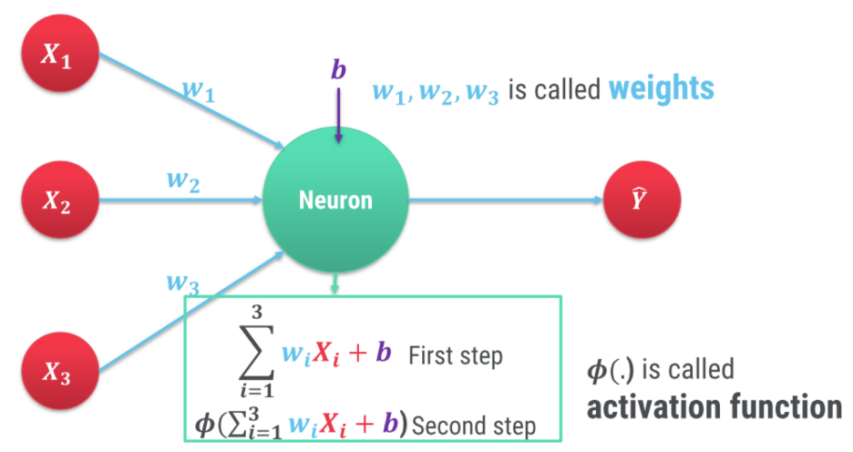

Langkah-langkah pada ANN:

1. Inisiasi nilai *synapse weights*, bisa random ataupun dengan aturan tertentu.
2. Lewatkan input pada neuron, kemudian kita akan mendapatkan nilai output. Kegiatan ini disebut *feedforward*.
3. Nilai output (*actual output*) tersebut dibandingkan dengan *desired output*.
4. Apabila nilai output sesuai dengan *desired output*, tidak perlu mengubah apa-apa.
5. Apabila nilai output tidak sesuai dengan *desired output*, hitung nilai error (*loss*) kemudian lakukan perubahan terhadap *learning parameter* (*synapse weight*).
6. Ulangi langkah-langkah ini sampai tidak ada perubahan nilai error, nilai error kurang dari atau sama dengan suatu *threshold* (biasanya mendekati 0), atau sudah mengulangi proses latihan sebanyak T kali (*threshold*).

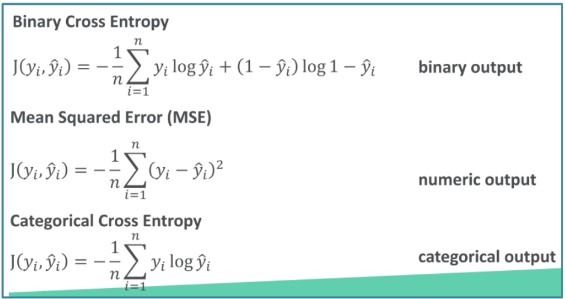

# Libraries (Tensorflow & Keras)

```r
#install.packages("tensorflow")
#install.packages("keras")
```

```r
#library("reticulate")
#virtualenv_create("r-reticulate2", python = install_python())
#tensorflow::install_tensorflow()
#keras::install_keras()

# Delete Installation
#unlink("~/.virtualenvs/r-tensorflow", recursive = TRUE)
```

# Model Klasifikasi Neural Network

## Data

```r
data <- read.csv("C:/Users/Irsyadobby/Documents/TPM/ObesityDataSet.csv", stringsAsFactors = T)
head(data)
```

```
##   Gender Age Height Weight family_history_with_overweight FAVC FCVC NCP
## 1 Female  21   1.62   64.0                            yes   no    2   3
## 2 Female  21   1.52   56.0                            yes   no    3   3
## 3   Male  23   1.80   77.0                            yes   no    2   3
## 4   Male  27   1.80   87.0                             no   no    3   3
## 5   Male  22   1.78   89.8                             no   no    2   1
## 6   Male  29   1.62   53.0                             no  yes    2   3
##        CAEC SMOKE CH2O SCC FAF TUE       CALC                MTRANS
## 1 Sometimes    no    2  no   0   1         no Public_Transportation
## 2 Sometimes   yes    3 yes   3   0  Sometimes Public_Transportation
## 3 Sometimes    no    2  no   2   1 Frequently Public_Transportation
## 4 Sometimes    no    2  no   2   0 Frequently               Walking
## 5 Sometimes    no    2  no   0   0  Sometimes Public_Transportation
## 6 Sometimes    no    2  no   0   0  Sometimes            Automobile
##            NObeyesdad
## 1       Normal_Weight
## 2       Normal_Weight
## 3       Normal_Weight
## 4  Overweight_Level_I
## 5 Overweight_Level_II
## 6       Normal_Weight
```

```r
str(data)
```

```
## 'data.frame':    2111 obs. of  17 variables:
##  $ Gender                        : Factor w/ 2 levels "Female","Male": 1 1 2 2 2 2 1 2 2 2 ...
##  $ Age                           : num  21 21 23 27 22 29 23 22 24 22 ...
##  $ Height                        : num  1.62 1.52 1.8 1.8 1.78 1.62 1.5 1.64 1.78 1.72 ...
##  $ Weight                        : num  64 56 77 87 89.8 53 55 53 64 68 ...
##  $ family_history_with_overweight: Factor w/ 2 levels "no","yes": 2 2 2 1 1 1 2 1 2 2 ...
##  $ FAVC                          : Factor w/ 2 levels "no","yes": 1 1 1 1 1 2 2 1 2 2 ...
##  $ FCVC                          : num  2 3 2 3 2 2 3 2 3 2 ...
##  $ NCP                           : num  3 3 3 3 1 3 3 3 3 3 ...
##  $ CAEC                          : Factor w/ 4 levels "Always","Frequently",..: 4 4 4 4 4 4 4 4 4 4 ...
##  $ SMOKE                         : Factor w/ 2 levels "no","yes": 1 2 1 1 1 1 1 1 1 1 ...
##  $ CH2O                          : num  2 3 2 2 2 2 2 2 2 2 ...
##  $ SCC                           : Factor w/ 2 levels "no","yes": 1 2 1 1 1 1 1 1 1 1 ...
##  $ FAF                           : num  0 3 2 2 0 0 1 3 1 1 ...
##  $ TUE                           : num  1 0 1 0 0 0 0 0 1 1 ...
##  $ CALC                          : Factor w/ 4 levels "Always","Frequently",..: 3 4 2 2 4 4 4 4 2 3 ...
##  $ MTRANS                        : Factor w/ 5 levels "Automobile","Bike",..: 4 4 4 5 4 1 3 4 4 4 ...
##  $ NObeyesdad                    : Factor w/ 7 levels "Insufficient_Weight",..: 2 2 2 6 7 2 2 2 2 2 ...
```

```r
summary(data)
```

```
##     Gender          Age            Height          Weight
##  Female:1043   Min.   :14.00   Min.   :1.450   Min.   : 39.00
##  Male  :1068   1st Qu.:19.95   1st Qu.:1.630   1st Qu.: 65.47
##                Median :22.78   Median :1.700   Median : 83.00
##                Mean   :24.31   Mean   :1.702   Mean   : 86.59
##                3rd Qu.:26.00   3rd Qu.:1.768   3rd Qu.:107.43
##                Max.   :61.00   Max.   :1.980   Max.   :173.00
##
##  family_history_with_overweight  FAVC           FCVC            NCP
##  no : 385                       no : 245   Min.   :1.000   Min.   :1.000
##  yes:1726                       yes:1866   1st Qu.:2.000   1st Qu.:2.659
##                                            Median :2.386   Median :3.000
##                                            Mean   :2.419   Mean   :2.686
##                                            3rd Qu.:3.000   3rd Qu.:3.000
##                                            Max.   :3.000   Max.   :4.000
##
##          CAEC      SMOKE           CH2O        SCC            FAF
##  Always    :  53   no :2067   Min.   :1.000   no :2015   Min.   :0.0000
##  Frequently: 242   yes:  44   1st Qu.:1.585   yes:  96   1st Qu.:0.1245
##  no        :  51              Median :2.000              Median :1.0000
##  Sometimes :1765              Mean   :2.008              Mean   :1.0103
##                               3rd Qu.:2.477              3rd Qu.:1.6667
##                               Max.   :3.000              Max.   :3.0000
##
##       TUE                 CALC                        MTRANS
##  Min.   :0.0000   Always    :   1   Automobile           : 457
##  1st Qu.:0.0000   Frequently:  70   Bike                 :   7
##  Median :0.6253   no        : 639   Motorbike            :  11
##  Mean   :0.6579   Sometimes :1401   Public_Transportation:1580
##  3rd Qu.:1.0000                     Walking              :  56
##  Max.   :2.0000
##
##                NObeyesdad
##  Insufficient_Weight:272
##  Normal_Weight      :287
##  Obesity_Type_I     :351
##  Obesity_Type_II    :297
##  Obesity_Type_III   :324
##  Overweight_Level_I :290
##  Overweight_Level_II:290
```

## Cek Missing Value

```r
colSums(is.na(data))
```

```
##                         Gender                            Age
##                              0                              0
##                         Height                         Weight
##                              0                              0
## family_history_with_overweight                           FAVC
##                              0                              0
##                           FCVC                            NCP
##                              0                              0
##                           CAEC                          SMOKE
##                              0                              0
##                           CH2O                            SCC
##                              0                              0
##                            FAF                            TUE
##                              0                              0
##                           CALC                         MTRANS
##                              0                              0
##                     NObeyesdad
##                              0
```

## Encoding Peubah Kategorik

```r
library("tensorflow")
library("keras")
library("caret")
# One-Hot Encoder
for(i in 1:(dim(data)[2] - 1)){
  if(is.factor(data[,i]) == TRUE){
    data[,i] <- to_categorical(as.integer(data[,i]) - 1)
  }
}

# Contoh Hasil One-Hot Encoder
head(data$MTRANS)
```

```
##      [,1] [,2] [,3] [,4] [,5]
## [1,]    0    0    0    1    0
## [2,]    0    0    0    1    0
## [3,]    0    0    0    1    0
## [4,]    0    0    0    0    1
## [5,]    0    0    0    1    0
## [6,]    1    0    0    0    0
```

## Splitting Data & Scaling

```r
set.seed(123)

# Train-Testing Split
train.index <- createDataPartition(data$NObeyesdad, p = 0.8, list = F)
train <- data[train.index, ]
test <- data[-train.index, ]

# Feature Scaling (Min-Max)
preprocessParams <- preProcess(train[, -17], method = "range")
train_X <- as.matrix(predict(preprocessParams, train[, -17]))
test_X <- as.matrix(predict(preprocessParams, test[, -17]))

# Encoding Variabel Respons
train_y <- to_categorical(as.integer(train[, 17])-1)
test_y <- to_categorical(as.integer(test[, 17])-1)
```

# Model 1 Layer

```r
# Arsitektur Model
model <- keras_model_sequential() %>%
  layer_dense(units = 64, activation = "relu", input_shape = ncol(train_X)) %>%
  layer_dense(units = ncol(train_y), activation = "softmax")

# Kompilasi Model
model %>% compile(
  loss = "categorical_crossentropy",
  optimizer = "adam",
  metrics = c("accuracy")
)

print(model)
```

```
## Model: "sequential"
## ________________________________________________________________________________
##  Layer (type)                       Output Shape                    Param #
## ================================================================================
##  dense_1 (Dense)                    (None, 64)                      2048
##  dense (Dense)                      (None, 7)                       455
## ================================================================================
## Total params: 2503 (9.78 KB)
## Trainable params: 2503 (9.78 KB)
## Non-trainable params: 0 (0.00 Byte)
## ________________________________________________________________________________
```

```r
# Training Model
history <- model %>% fit(
  train_X, train_y,
  shuffle = T,
  epochs = 100,
  batch_size = 32,
  validation_split = 0.2
)
```

```
## 43/43 - 0s - loss: 1.8596 - accuracy: 0.1797 - val_loss: 3.0764 - val_accuracy: 0.0000e+00 - 411ms/epoch - 10ms/step
## 43/43 - 0s - loss: 1.6976 - accuracy: 0.2988 - val_loss: 3.4507 - val_accuracy: 0.0000e+00 - 71ms/epoch - 2ms/step
## 43/43 - 0s - loss: 1.5731 - accuracy: 0.3772 - val_loss: 3.6741 - val_accuracy: 0.0147 - 62ms/epoch - 1ms/step
## 43/43 - 0s - loss: 1.4632 - accuracy: 0.4578 - val_loss: 3.5656 - val_accuracy: 0.1091 - 62ms/epoch - 1ms/step
## 43/43 - 0s - loss: 1.3818 - accuracy: 0.5022 - val_loss: 3.5815 - val_accuracy: 0.1150 - 62ms/epoch - 1ms/step
## 43/43 - 0s - loss: 1.3177 - accuracy: 0.5237 - val_loss: 3.5455 - val_accuracy: 0.0560 - 60ms/epoch - 1ms/step
## 43/43 - 0s - loss: 1.2691 - accuracy: 0.5473 - val_loss: 3.3939 - val_accuracy: 0.1534 - 61ms/epoch - 1ms/step
## 43/43 - 0s - loss: 1.2245 - accuracy: 0.5717 - val_loss: 3.3677 - val_accuracy: 0.2094 - 59ms/epoch - 1ms/step
## 43/43 - 0s - loss: 1.1882 - accuracy: 0.5769 - val_loss: 3.1624 - val_accuracy: 0.2537 - 59ms/epoch - 1ms/step
## 43/43 - 0s - loss: 1.1580 - accuracy: 0.6065 - val_loss: 3.1871 - val_accuracy: 0.2242 - 60ms/epoch - 1ms/step
## 43/43 - 0s - loss: 1.1269 - accuracy: 0.6243 - val_loss: 3.0618 - val_accuracy: 0.2537 - 58ms/epoch - 1ms/step
## 43/43 - 0s - loss: 1.0940 - accuracy: 0.6302 - val_loss: 2.9569 - val_accuracy: 0.2360 - 56ms/epoch - 1ms/step
## 43/43 - 0s - loss: 1.0708 - accuracy: 0.6398 - val_loss: 2.9039 - val_accuracy: 0.2242 - 57ms/epoch - 1ms/step
## 43/43 - 0s - loss: 1.0431 - accuracy: 0.6442 - val_loss: 2.7828 - val_accuracy: 0.2655 - 56ms/epoch - 1ms/step
## 43/43 - 0s - loss: 1.0231 - accuracy: 0.6598 - val_loss: 2.6830 - val_accuracy: 0.2655 - 55ms/epoch - 1ms/step
## 43/43 - 0s - loss: 0.9998 - accuracy: 0.6605 - val_loss: 2.5993 - val_accuracy: 0.2360 - 57ms/epoch - 1ms/step
## 43/43 - 0s - loss: 0.9760 - accuracy: 0.6598 - val_loss: 2.5075 - val_accuracy: 0.2655 - 57ms/epoch - 1ms/step
## 43/43 - 0s - loss: 0.9588 - accuracy: 0.6738 - val_loss: 2.5177 - val_accuracy: 0.2507 - 58ms/epoch - 1ms/step
## 43/43 - 0s - loss: 0.9385 - accuracy: 0.6945 - val_loss: 2.4895 - val_accuracy: 0.2389 - 62ms/epoch - 1ms/step
## 43/43 - 0s - loss: 0.9207 - accuracy: 0.6834 - val_loss: 2.2491 - val_accuracy: 0.2389 - 62ms/epoch - 1ms/step
## 43/43 - 0s - loss: 0.9021 - accuracy: 0.6930 - val_loss: 2.2304 - val_accuracy: 0.2655 - 61ms/epoch - 1ms/step
## 43/43 - 0s - loss: 0.8881 - accuracy: 0.6967 - val_loss: 2.1730 - val_accuracy: 0.2625 - 62ms/epoch - 1ms/step
## 43/43 - 0s - loss: 0.8653 - accuracy: 0.7101 - val_loss: 2.1940 - val_accuracy: 0.2448 - 61ms/epoch - 1ms/step
## 43/43 - 0s - loss: 0.8495 - accuracy: 0.7108 - val_loss: 1.9734 - val_accuracy: 0.2684 - 63ms/epoch - 1ms/step
## 43/43 - 0s - loss: 0.8336 - accuracy: 0.7256 - val_loss: 1.8915 - val_accuracy: 0.2655 - 61ms/epoch - 1ms/step
## 43/43 - 0s - loss: 0.8191 - accuracy: 0.7234 - val_loss: 1.9086 - val_accuracy: 0.2684 - 63ms/epoch - 1ms/step
## 43/43 - 0s - loss: 0.8054 - accuracy: 0.7337 - val_loss: 1.8599 - val_accuracy: 0.2625 - 66ms/epoch - 2ms/step
## 43/43 - 0s - loss: 0.7886 - accuracy: 0.7345 - val_loss: 1.7598 - val_accuracy: 0.2684 - 63ms/epoch - 1ms/step
## 43/43 - 0s - loss: 0.7722 - accuracy: 0.7352 - val_loss: 1.7209 - val_accuracy: 0.2684 - 63ms/epoch - 1ms/step
## 43/43 - 0s - loss: 0.7604 - accuracy: 0.7396 - val_loss: 1.6202 - val_accuracy: 0.2478 - 62ms/epoch - 1ms/step
## 43/43 - 0s - loss: 0.7456 - accuracy: 0.7500 - val_loss: 1.6075 - val_accuracy: 0.2596 - 61ms/epoch - 1ms/step
## 43/43 - 0s - loss: 0.7333 - accuracy: 0.7485 - val_loss: 1.3987 - val_accuracy: 0.2684 - 60ms/epoch - 1ms/step
## 43/43 - 0s - loss: 0.7171 - accuracy: 0.7596 - val_loss: 1.4296 - val_accuracy: 0.2655 - 62ms/epoch - 1ms/step
## 43/43 - 0s - loss: 0.7041 - accuracy: 0.7574 - val_loss: 1.3534 - val_accuracy: 0.2566 - 62ms/epoch - 1ms/step
## 43/43 - 0s - loss: 0.6913 - accuracy: 0.7685 - val_loss: 1.3987 - val_accuracy: 0.2478 - 62ms/epoch - 1ms/step
## 43/43 - 0s - loss: 0.6813 - accuracy: 0.7618 - val_loss: 1.2566 - val_accuracy: 0.2655 - 70ms/epoch - 2ms/step
## 43/43 - 0s - loss: 0.6690 - accuracy: 0.7707 - val_loss: 1.3147 - val_accuracy: 0.2625 - 61ms/epoch - 1ms/step
## 43/43 - 0s - loss: 0.6549 - accuracy: 0.7766 - val_loss: 1.1153 - val_accuracy: 0.2684 - 65ms/epoch - 2ms/step
## 43/43 - 0s - loss: 0.6451 - accuracy: 0.7788 - val_loss: 1.0838 - val_accuracy: 0.2655 - 60ms/epoch - 1ms/step
## 43/43 - 0s - loss: 0.6367 - accuracy: 0.7788 - val_loss: 1.1439 - val_accuracy: 0.2655 - 62ms/epoch - 1ms/step
```

[output cut: 45 more lines]

```
## 43/43 - 0s - loss: 0.3232 - accuracy: 0.9209 - val_loss: 0.1729 - val_accuracy: 1.0000 - 59ms/epoch - 1ms/step
## 43/43 - 0s - loss: 0.3217 - accuracy: 0.9164 - val_loss: 0.1860 - val_accuracy: 1.0000 - 63ms/epoch - 1ms/step
## 43/43 - 0s - loss: 0.3143 - accuracy: 0.9209 - val_loss: 0.2530 - val_accuracy: 0.9971 - 62ms/epoch - 1ms/step
## 43/43 - 0s - loss: 0.3111 - accuracy: 0.9201 - val_loss: 0.2244 - val_accuracy: 0.9971 - 59ms/epoch - 1ms/step
## 43/43 - 0s - loss: 0.3058 - accuracy: 0.9209 - val_loss: 0.1791 - val_accuracy: 0.9971 - 64ms/epoch - 1ms/step
## 43/43 - 0s - loss: 0.3020 - accuracy: 0.9231 - val_loss: 0.1714 - val_accuracy: 0.9971 - 64ms/epoch - 1ms/step
## 43/43 - 0s - loss: 0.3007 - accuracy: 0.9209 - val_loss: 0.1595 - val_accuracy: 1.0000 - 62ms/epoch - 1ms/step
## 43/43 - 0s - loss: 0.2962 - accuracy: 0.9268 - val_loss: 0.1568 - val_accuracy: 1.0000 - 60ms/epoch - 1ms/step
## 43/43 - 0s - loss: 0.2927 - accuracy: 0.9290 - val_loss: 0.1653 - val_accuracy: 0.9971 - 60ms/epoch - 1ms/step
## 43/43 - 0s - loss: 0.2877 - accuracy: 0.9327 - val_loss: 0.1849 - val_accuracy: 0.9971 - 64ms/epoch - 1ms/step
## 43/43 - 0s - loss: 0.2856 - accuracy: 0.9312 - val_loss: 0.1652 - val_accuracy: 1.0000 - 65ms/epoch - 2ms/step
## 43/43 - 0s - loss: 0.2839 - accuracy: 0.9297 - val_loss: 0.1599 - val_accuracy: 1.0000 - 62ms/epoch - 1ms/step
## 43/43 - 0s - loss: 0.2795 - accuracy: 0.9260 - val_loss: 0.1669 - val_accuracy: 1.0000 - 62ms/epoch - 1ms/step
## 43/43 - 0s - loss: 0.2748 - accuracy: 0.9371 - val_loss: 0.1344 - val_accuracy: 1.0000 - 64ms/epoch - 1ms/step
## 43/43 - 0s - loss: 0.2732 - accuracy: 0.9305 - val_loss: 0.1726 - val_accuracy: 0.9971 - 61ms/epoch - 1ms/step
```

```r
# Evaluasi Model dengan data Test
scores <- model %>% evaluate(test_X, test_y)
```

```
## 14/14 - 0s - loss: 0.4418 - accuracy: 0.8690 - 23ms/epoch - 2ms/step
```

```r
print(scores)
```

```
##      loss  accuracy
## 0.4417673 0.8690476
```

## Prediksi Model

```r
# Prediksi dalam bentuk peluang
pred <- predict(model, test_X)
```

```
## 14/14 - 0s - 94ms/epoch - 7ms/step
```

```r
head(pred)
```

```
##              [,1]        [,2]        [,3]         [,4]         [,5]       [,6]
## [1,] 5.819316e-04 0.129241377 0.001999819 3.373366e-06 9.032531e-06 0.01108119
## [2,] 3.514144e-06 0.020193741 0.017087951 1.172182e-03 2.550956e-06 0.07509536
## [3,] 7.801218e-06 0.015344511 0.088550463 1.013516e-02 6.167735e-03 0.04611303
## [4,] 9.174605e-07 0.068781011 0.239746511 2.375239e-04 2.666123e-05 0.59222496
## [5,] 8.141182e-05 0.745090425 0.162075162 9.711960e-04 2.967236e-06 0.03499089
## [6,] 1.040176e-06 0.003833564 0.758471251 1.745495e-04 4.139393e-04 0.15054619
##            [,7]
## [1,] 0.85708332
## [2,] 0.88644469
## [3,] 0.83368129
## [4,] 0.09898236
## [5,] 0.05678804
## [6,] 0.08655939
```

```r
# Prediksi Label
label_pred <- apply(pred, 1, which.max)
label_pred
```

```
##   [1] 7 7 7 6 2 3 2 2 6 7 2 2 2 2 1 2 2 7 2 2 2 2 2 1 2 7 2 2 6 2 2 7 2 2 7 2 2
##  [38] 7 4 1 7 3 2 6 3 2 4 6 7 2 2 6 2 3 2 2 7 1 2 2 2 6 2 2 2 2 1 2 2 2 3 2 2 2
##  [75] 3 6 2 3 2 2 2 2 6 2 2 2 2 2 6 2 6 2 2 2 2 2 1 2 2 2 2 6 6 7 1 1 1 1 1 1 1
## [112] 1 1 1 1 1 1 1 1 1 1 1 1 1 1 1 1 2 1 1 1 1 1 1 1 1 1 1 1 1 1 1 1 1 1 1 1 1
## [149] 1 6 6 6 6 6 6 6 6 6 6 6 6 6 7 6 6 6 6 6 6 7 7 6 7 6 6 6 6 6 6 6 6 6 6 6 6
## [186] 7 6 6 6 6 7 6 6 6 7 6 6 6 7 7 7 6 7 7 7 7 7 7 7 6 7 7 7 7 7 3 7 7 7 7 7 7
## [223] 7 7 7 6 7 7 7 7 3 7 6 7 7 7 7 3 7 7 7 7 3 3 3 3 3 3 3 3 3 3 3 3 3 7 3 4 3
## [260] 7 3 3 7 3 3 3 3 3 3 3 3 3 3 3 3 3 3 3 3 3 3 3 3 7 3 3 3 3 3 3 3 3 3 3 3 3
## [297] 3 3 3 4 4 4 4 4 4 4 4 4 3 4 4 4 4 4 4 4 4 4 4 4 4 4 4 4 4 4 4 4 4 4 4 4 4
## [334] 4 4 4 4 4 4 4 4 4 4 4 4 4 4 4 4 4 4 4 4 4 4 4 5 5 5 5 5 5 5 5 5 5 5 5 5 5
## [371] 5 5 5 5 5 5 5 5 5 5 5 5 5 5 5 5 5 5 5 5 5 5 5 5 5 5 5 5 5 5 5 5 5 5 5 5 5
## [408] 5 5 5 5 5 5 5 5 5 5 5 5 5
```

```r
# Nilai aktual
label_true <- as.integer(test$NObeyesdad)
label_true
```

```
##   [1] 2 7 3 3 7 3 2 2 2 7 2 2 2 2 1 1 2 7 6 2 2 6 2 2 2 7 2 6 3 2 6 7 2 7 7 2 2
##  [38] 3 4 2 3 3 2 6 3 2 4 6 2 2 2 2 2 7 1 2 3 1 7 2 2 2 2 2 1 2 1 2 2 2 3 2 2 2
##  [75] 3 2 2 7 6 2 2 3 6 1 2 1 2 2 7 2 7 2 3 2 2 2 1 2 2 2 2 6 2 7 1 1 1 1 1 1 1
## [112] 1 1 1 1 1 1 1 1 1 1 1 1 1 1 1 1 1 1 1 1 1 1 1 1 1 1 1 1 1 1 1 1 1 1 1 1 1
## [149] 1 6 6 6 6 6 6 6 6 6 6 6 6 6 6 6 6 6 6 6 6 6 6 6 6 6 6 6 6 6 6 6 6 6 6 6 6
## [186] 6 6 6 6 6 6 6 6 6 6 6 6 6 7 7 7 7 7 7 7 7 7 7 7 7 7 7 7 7 7 7 7 7 7 7 7 7
## [223] 7 7 7 7 7 7 7 7 7 7 7 7 7 7 7 7 7 7 7 7 3 3 3 3 3 3 3 3 3 3 3 3 3 3 3 3 3
## [260] 3 3 3 3 3 3 3 3 3 3 3 3 3 3 3 3 3 3 3 3 3 3 3 3 3 3 3 3 3 3 3 3 3 3 3 3 3
## [297] 3 3 3 4 4 4 4 4 4 4 4 4 4 4 4 4 4 4 4 4 4 4 4 4 4 4 4 4 4 4 4 4 4 4 4 4 4
## [334] 4 4 4 4 4 4 4 4 4 4 4 4 4 4 4 4 4 4 4 4 4 4 4 5 5 5 5 5 5 5 5 5 5 5 5 5 5
## [371] 5 5 5 5 5 5 5 5 5 5 5 5 5 5 5 5 5 5 5 5 5 5 5 5 5 5 5 5 5 5 5 5 5 5 5 5 5
## [408] 5 5 5 5 5 5 5 5 5 5 5 5 5
```

## Evaluasi Model

```r
confusionMatrix(as.factor(label_true), as.factor(label_pred))
```

```
## Confusion Matrix and Statistics
##
##           Reference
## Prediction  1  2  3  4  5  6  7
##          1 48  6  0  0  0  0  0
##          2  2 48  0  0  0  5  2
##          3  0  2 57  1  0  2  8
##          4  0  0  1 58  0  0  0
##          5  0  0  0  0 64  0  0
##          6  0  5  0  0  0 46  7
##          7  0  3  5  0  0  6 44
##
## Overall Statistics
##
##                Accuracy : 0.869
##                  95% CI : (0.833, 0.8998)
##     No Information Rate : 0.1524
##     P-Value [Acc > NIR] : < 2.2e-16
##
##                   Kappa : 0.8471
##
##  Mcnemar's Test P-Value : NA
##
## Statistics by Class:
##
##                      Class: 1 Class: 2 Class: 3 Class: 4 Class: 5 Class: 6
## Sensitivity            0.9600   0.7500   0.9048   0.9831   1.0000   0.7797
## Specificity            0.9838   0.9747   0.9636   0.9972   1.0000   0.9668
## Pos Pred Value         0.8889   0.8421   0.8143   0.9831   1.0000   0.7931
## Neg Pred Value         0.9945   0.9559   0.9829   0.9972   1.0000   0.9641
## Prevalence             0.1190   0.1524   0.1500   0.1405   0.1524   0.1405
## Detection Rate         0.1143   0.1143   0.1357   0.1381   0.1524   0.1095
## Detection Prevalence   0.1286   0.1357   0.1667   0.1405   0.1524   0.1381
## Balanced Accuracy      0.9719   0.8624   0.9342   0.9901   1.0000   0.8732
##                      Class: 7
## Sensitivity            0.7213
## Specificity            0.9610
## Pos Pred Value         0.7586
## Neg Pred Value         0.9530
## Prevalence             0.1452
## Detection Rate         0.1048
## Detection Prevalence   0.1381
## Balanced Accuracy      0.8412
```

# Model Regresi

```r
data.ab <- read.csv("C:/Users/Irsyadobby/Documents/TPM/abalone.csv", stringsAsFactors = T)
head(data.ab)
```

```
##   Sex Length Diameter Height Whole.weight Shucked.weight Viscera.weight
## 1   M  0.455    0.365  0.095       0.5140         0.2245         0.1010
## 2   M  0.350    0.265  0.090       0.2255         0.0995         0.0485
## 3   F  0.530    0.420  0.135       0.6770         0.2565         0.1415
## 4   M  0.440    0.365  0.125       0.5160         0.2155         0.1140
## 5   I  0.330    0.255  0.080       0.2050         0.0895         0.0395
## 6   I  0.425    0.300  0.095       0.3515         0.1410         0.0775
##   Shell.weight Rings
## 1        0.150    15
## 2        0.070     7
## 3        0.210     9
## 4        0.155    10
## 5        0.055     7
## 6        0.120     8
```

```r
str(data.ab)
```

```
## 'data.frame':    4177 obs. of  9 variables:
##  $ Sex           : Factor w/ 3 levels "F","I","M": 3 3 1 3 2 2 1 1 3 1 ...
##  $ Length        : num  0.455 0.35 0.53 0.44 0.33 0.425 0.53 0.545 0.475 0.55 ...
##  $ Diameter      : num  0.365 0.265 0.42 0.365 0.255 0.3 0.415 0.425 0.37 0.44 ...
##  $ Height        : num  0.095 0.09 0.135 0.125 0.08 0.095 0.15 0.125 0.125 0.15 ...
##  $ Whole.weight  : num  0.514 0.226 0.677 0.516 0.205 ...
##  $ Shucked.weight: num  0.2245 0.0995 0.2565 0.2155 0.0895 ...
##  $ Viscera.weight: num  0.101 0.0485 0.1415 0.114 0.0395 ...
##  $ Shell.weight  : num  0.15 0.07 0.21 0.155 0.055 0.12 0.33 0.26 0.165 0.32 ...
##  $ Rings         : int  15 7 9 10 7 8 20 16 9 19 ...
```

```r
# Cek Missing Value
colSums(is.na(data.ab))
```

```
##            Sex         Length       Diameter         Height   Whole.weight
##              0              0              0              0              0
## Shucked.weight Viscera.weight   Shell.weight          Rings
##              0              0              0              0
```

## Feature Engineering

```r
# Menambahkan Kolom 'Age'
data.ab$Age <- data.ab$Rings + 1.5

# Menghapus Kolom 'Rings'
data.ab$Rings <- NULL

# One-Hot Encoding Kolom 'Sex'
data.ab$Sex <- to_categorical(as.integer(data.ab$Sex) - 1)
```

## Splitting & Scaling

```r
set.seed(123)

train.index <- createDataPartition(data.ab$Age, p = 0.8, list = FALSE)
train <- data.ab[train.index, ]
test <- data.ab[-train.index, ]

# Melakukan Feature Scaling min max (0, 1)
preprocessParams <- preProcess(train[, -9], method=c("range"))
train_X <- as.matrix(predict(preprocessParams, train[, -9]))
test_X <- as.matrix(predict(preprocessParams, test[, -9]))

train_y <- train[, 9]
test_y <- test[, 9]
```

## Pemodelan

```r
# Membuat model neural network dengan 2 hidden layer
model <- keras_model_sequential() %>%
  layer_dense(units = 64, activation = "relu", input_shape = ncol(train_X)) %>%
  layer_dropout(0.3) %>%
  layer_dense(units = 64, activation = "relu") %>%
  layer_dropout(0.3) %>%
  layer_dense(units = 1, activation = "linear")

# Mengkompilasi model
model %>% compile(
  loss = "mean_squared_error",
  optimizer = "adam",
  metrics = list("mean_squared_error", "mean_absolute_error")
)

# Melakukan tahapan pelatihan model
history <- model %>% fit(
  train_X, train_y,
  shuffle = T,
  epochs = 50,
  batch_size = 32,
  validation_split = 0.2
)
```

```
## 84/84 - 1s - loss: 67.2290 - mean_squared_error: 67.2290 - mean_absolute_error: 6.9001 - val_loss: 7.9994 - val_mean_squared_error: 7.9994 - val_mean_absolute_error: 2.2096 - 526ms/epoch - 6ms/step
## 84/84 - 0s - loss: 11.8588 - mean_squared_error: 11.8588 - mean_absolute_error: 2.5534 - val_loss: 5.5463 - val_mean_squared_error: 5.5463 - val_mean_absolute_error: 1.6303 - 114ms/epoch - 1ms/step
## 84/84 - 0s - loss: 10.6022 - mean_squared_error: 10.6022 - mean_absolute_error: 2.4205 - val_loss: 5.5212 - val_mean_squared_error: 5.5212 - val_mean_absolute_error: 1.7584 - 123ms/epoch - 1ms/step
## 84/84 - 0s - loss: 10.3165 - mean_squared_error: 10.3165 - mean_absolute_error: 2.3814 - val_loss: 5.0169 - val_mean_squared_error: 5.0169 - val_mean_absolute_error: 1.5364 - 120ms/epoch - 1ms/step
## 84/84 - 0s - loss: 9.8971 - mean_squared_error: 9.8971 - mean_absolute_error: 2.3137 - val_loss: 5.0078 - val_mean_squared_error: 5.0078 - val_mean_absolute_error: 1.6592 - 121ms/epoch - 1ms/step
## 84/84 - 0s - loss: 9.4093 - mean_squared_error: 9.4093 - mean_absolute_error: 2.2854 - val_loss: 4.7403 - val_mean_squared_error: 4.7403 - val_mean_absolute_error: 1.5378 - 117ms/epoch - 1ms/step
## 84/84 - 0s - loss: 9.2687 - mean_squared_error: 9.2687 - mean_absolute_error: 2.2341 - val_loss: 4.6099 - val_mean_squared_error: 4.6099 - val_mean_absolute_error: 1.5196 - 117ms/epoch - 1ms/step
## 84/84 - 0s - loss: 9.1202 - mean_squared_error: 9.1202 - mean_absolute_error: 2.2226 - val_loss: 4.5504 - val_mean_squared_error: 4.5504 - val_mean_absolute_error: 1.5317 - 114ms/epoch - 1ms/step
## 84/84 - 0s - loss: 9.4460 - mean_squared_error: 9.4460 - mean_absolute_error: 2.2485 - val_loss: 4.5945 - val_mean_squared_error: 4.5945 - val_mean_absolute_error: 1.5659 - 117ms/epoch - 1ms/step
## 84/84 - 0s - loss: 9.0684 - mean_squared_error: 9.0684 - mean_absolute_error: 2.2150 - val_loss: 4.4088 - val_mean_squared_error: 4.4088 - val_mean_absolute_error: 1.4357 - 114ms/epoch - 1ms/step
## 84/84 - 0s - loss: 8.9506 - mean_squared_error: 8.9506 - mean_absolute_error: 2.1972 - val_loss: 4.9752 - val_mean_squared_error: 4.9752 - val_mean_absolute_error: 1.7505 - 116ms/epoch - 1ms/step
## 84/84 - 0s - loss: 8.9275 - mean_squared_error: 8.9275 - mean_absolute_error: 2.2146 - val_loss: 4.5104 - val_mean_squared_error: 4.5104 - val_mean_absolute_error: 1.5733 - 123ms/epoch - 1ms/step
## 84/84 - 0s - loss: 8.2312 - mean_squared_error: 8.2312 - mean_absolute_error: 2.1552 - val_loss: 4.2631 - val_mean_squared_error: 4.2631 - val_mean_absolute_error: 1.4715 - 113ms/epoch - 1ms/step
## 84/84 - 0s - loss: 8.4160 - mean_squared_error: 8.4160 - mean_absolute_error: 2.1289 - val_loss: 4.1601 - val_mean_squared_error: 4.1601 - val_mean_absolute_error: 1.4329 - 107ms/epoch - 1ms/step
## 84/84 - 0s - loss: 8.2936 - mean_squared_error: 8.2936 - mean_absolute_error: 2.1089 - val_loss: 4.1266 - val_mean_squared_error: 4.1266 - val_mean_absolute_error: 1.4595 - 106ms/epoch - 1ms/step
## 84/84 - 0s - loss: 8.1500 - mean_squared_error: 8.1500 - mean_absolute_error: 2.0873 - val_loss: 4.1255 - val_mean_squared_error: 4.1255 - val_mean_absolute_error: 1.4911 - 105ms/epoch - 1ms/step
## 84/84 - 0s - loss: 8.3623 - mean_squared_error: 8.3623 - mean_absolute_error: 2.1536 - val_loss: 4.0596 - val_mean_squared_error: 4.0596 - val_mean_absolute_error: 1.4570 - 112ms/epoch - 1ms/step
## 84/84 - 0s - loss: 7.9003 - mean_squared_error: 7.9003 - mean_absolute_error: 2.0878 - val_loss: 3.9629 - val_mean_squared_error: 3.9629 - val_mean_absolute_error: 1.4218 - 116ms/epoch - 1ms/step
## 84/84 - 0s - loss: 7.8652 - mean_squared_error: 7.8652 - mean_absolute_error: 2.0826 - val_loss: 3.9499 - val_mean_squared_error: 3.9499 - val_mean_absolute_error: 1.4277 - 114ms/epoch - 1ms/step
## 84/84 - 0s - loss: 8.0257 - mean_squared_error: 8.0257 - mean_absolute_error: 2.0655 - val_loss: 3.9430 - val_mean_squared_error: 3.9430 - val_mean_absolute_error: 1.4424 - 121ms/epoch - 1ms/step
## 84/84 - 0s - loss: 7.5660 - mean_squared_error: 7.5660 - mean_absolute_error: 2.0173 - val_loss: 3.8536 - val_mean_squared_error: 3.8536 - val_mean_absolute_error: 1.3801 - 119ms/epoch - 1ms/step
## 84/84 - 0s - loss: 7.8128 - mean_squared_error: 7.8128 - mean_absolute_error: 2.0569 - val_loss: 3.8607 - val_mean_squared_error: 3.8607 - val_mean_absolute_error: 1.4004 - 117ms/epoch - 1ms/step
```

[output cut: 28 more lines]

```r
print(model)
```

```
## Model: "sequential_1"
## ________________________________________________________________________________
##  Layer (type)                       Output Shape                    Param #
## ================================================================================
##  dense_4 (Dense)                    (None, 64)                      704
##  dropout_1 (Dropout)                (None, 64)                      0
##  dense_3 (Dense)                    (None, 64)                      4160
##  dropout (Dropout)                  (None, 64)                      0
##  dense_2 (Dense)                    (None, 1)                       65
## ================================================================================
## Total params: 4929 (19.25 KB)
## Trainable params: 4929 (19.25 KB)
## Non-trainable params: 0 (0.00 Byte)
## ________________________________________________________________________________
```

## Prediksi

```r
prediksi <- predict(model, test_X)
```

```
## 27/27 - 0s - 49ms/epoch - 2ms/step
```

```r
head(prediksi)
```

```
##           [,1]
## [1,] 12.327397
## [2,]  9.339828
## [3,] 11.181221
## [4,] 12.179553
## [5,] 10.023915
## [6,] 11.693994
```

## Evaluasi Model

```r
# Mengevaluasi model menggunakan data uji
scores <- model %>% evaluate(test_X, test_y)
```

```
## 27/27 - 0s - loss: 5.4219 - mean_squared_error: 5.4219 - mean_absolute_error: 1.4981 - 29ms/epoch - 1ms/step
```

```r
print(scores)
```

```
##                loss  mean_squared_error mean_absolute_error
##            5.421887            5.421887            1.498140
```

```r
keras_train <- model %>% predict(train_X)
```

```
## 105/105 - 0s - 60ms/epoch - 571us/step
```

```r
keras_test <- model %>% predict(test_X)
```

```
## 27/27 - 0s - 28ms/epoch - 1ms/step
```

```r
# Training Evaluation
postResample(keras_train[,1], train$Age)
```

```
##      RMSE  Rsquared       MAE
## 2.1714826 0.5551772 1.5137445
```

```r
# Testing Evaluation
postResample(keras_test[,1], test$Age)
```

```
##      RMSE  Rsquared       MAE
## 2.3284945 0.4738014 1.4981400
```